# Assignment 10: Predictive Modeling - Part 1

## **1. Use the `Adult Census Income` dataset. We will predict the income (whether or not it is more than 50k or not) of an adult. Import the dataset. Partition the data into 80% training and 20% testing.**

```r
# import data
library(tidyverse)
df = read_csv("C:\\Users\\student\\Documents\\M461-Statistical-Analysis-with-R\\adult_census.csv")
```

```r
# rename income as target variable
df <- df %>%  rename(target = income)
```

```r
# correct variables' types
df <- df %>%
  mutate(target = as.factor(target),
         workclass = as.factor(workclass),
         education = as.factor(education),
         marital.status = as.factor(marital.status),
         occupation = as.factor(occupation),
         relationship = as.factor(relationship),
         race = as.factor(race),
         sex = as.factor(sex),
         native.country = as.factor(native.country))
```

```r
# handling missing values
df <- replace(df, df == 'Not Known' |
                df == 'Unknown' |
                df == '?' |
                df == 99999, NA)
```

```r
#dropping NAs
df = drop_na(df)
```

```r
#splitting 80% training, 20% testing
library(caret)
set.seed(2020)
splitIndex <- createDataPartition(df$target, p = .80,
                                   list = FALSE)
df_train <- df[splitIndex,]
df_test <- df[-splitIndex,]
```

## 2. **Practice Decision Tree. Do the follows:**

- Use `rpart` package, create a decision tree with maximum depth of 3.

```r
library(rpart)
tree_model <- rpart(target ~ ., data = df_train,
                    control = rpart.control(maxdepth = 3))
```

- Calculate the accuracy of the model on the testing data. Notice that the positive outcome here is not `1` but `>50K` or `<50K`.

```r
pred <- predict(tree_model, df_test, type = "class")

cm <- confusionMatrix(data = pred, reference = df_test$target, positive = ">50K")
cm$overall[1]
```

```
##  Accuracy
## 0.8467178
```

- Plot the tree

```r
library(rattle)
```

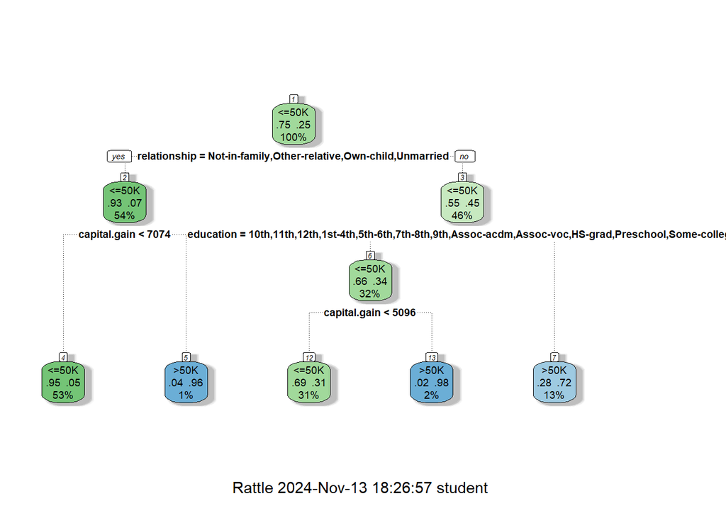

```r
fancyRpartPlot(tree_model)
```

- Plot the variable importance by the tree

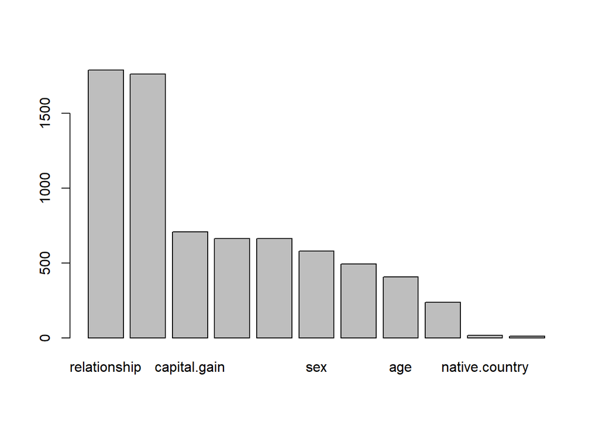

```r
barplot(tree_model$variable.importance)
```

## 3. Create 3 more trees and compare the testing accuracy of these trees, which tree give the highest testing accuracy.

```r
tree_model2 <- rpart(target ~ ., data = df_train,
                    control = rpart.control(minsplit = 5))

pred2 <- predict(tree_model2, df_test, type = "class")

cm2 <- confusionMatrix(data = pred2, reference = df_test$target, positive = ">50K")
cm2$overall[1]
```

```
##  Accuracy
## 0.8467178
```

### Tree # 3:

```r
tree_model3 <- rpart(target ~., data = df_train,
                     control = rpart.control(cp = 0.01))

pred3 <- predict(tree_model3, df_test, type = "class")

cm3 <- confusionMatrix(data = pred3, reference = df_test$target, positive = ">50K")

cm3$overall[1]
```

```
##  Accuracy
## 0.8467178
```

### Tree #4

```r
tree_model4 <- rpart(target ~., data = df_train,
                     control = rpart.control(minibucket = 5))

pred4 <- predict(tree_model4, df_test, type = "class")

cm4 <- confusionMatrix(data = pred4, reference = df_test$target, positive = ">50K")

cm4$overall[1]
```

```
##  Accuracy
## 0.8467178
```

**unsure why, but all three trees gave identical accuraces.**

## 4. Practice Random Forest. Do the follows:

- Use `randomForest` package, create a random forest of 1000 trees.

```r
library(randomForest)
```

```r
library(ggplot2)
forest_model = randomForest(target ~., data = df_train, ntree = 1000)
pred<- predict(forest_model, df_test, type = "class")

cm <- confusionMatrix(data = pred, reference = df_test$target, positive = ">50K")
```

- Calculate the accuracy of the model on the testing data.

```r
cm$overall[1]
```

```
##  Accuracy
## 0.8640453
```

- Plot the variable importance by the forest

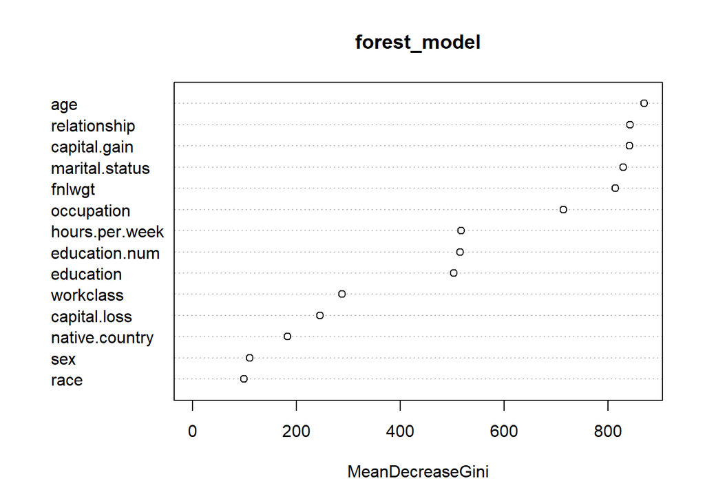

```r
varImpPlot(forest_model)
```

## 5. Create 3 more forests and compare the testing accuracy of these forests, which forest give the highest testing accuracy.

### Forest #2

```r
forest_model2 = randomForest(target ~., data = df_train, ntree = 1000, mtry = 3)
pred2<- predict(forest_model2, df_test, type = "class")

cm2 <- confusionMatrix(data = pred2, reference = df_test$target, positive = ">50K")

cm2$overall[1]
```

```
## Accuracy
## 0.862879
```

### Forest #3

```r
forest_model3 = randomForest(target ~., data = df_train, ntree = 1000, nodesize = 10)
pred3<- predict(forest_model3, df_test, type = "class")

cm3 <- confusionMatrix(data = pred3, reference = df_test$target, positive = ">50K")

cm3$overall[1]
```

```
##  Accuracy
## 0.8635455
```

### Forest #4

```r
forest_model4 = randomForest(target ~., data = df_train, ntree = 1000, maxnodes = 30)
pred4<- predict(forest_model4, df_test, type = "class")

cm4 <- confusionMatrix(data = pred4, reference = df_test$target, positive = ">50K")

cm4$overall[1]
```

```
##  Accuracy
## 0.8497168
```